# Simple features in R - geometries

Walter Humberto Subiza Pina

12/28/2020

## Geometry of spatial objects in R

The document refers exclusively to vector geometries, **sfg** objects from the *sf* library which are the fundamental block of the category of spatial or georeferenced objects in *R*.

The representation of objects on the Earth’s surface is done through vector objects of the type point, line or polygon and their multi variants. Also included is a new category, **geometrycollection**, not supported by the ESRI format of layer-type files (shp).

This new format has become increasingly common, since its inclusion in databases like *Postgre/Postgis* or data formats like *geoJSON*.

In the first part, we will see the creation of geometries, including **geometrycollection**. This is not the usual form of getting vector geometries, but it is necessary to understand the basis in order to prevent or solve errors in our projects.

In the second part, how to create **geometrycollection** objects from ESRI files and besides, how perform a extraction of their different components. This can be useful in case you need to create a single object containing several geometries to share data or store it in a database.

Finally in the third part, we save the **geometrycollection** in a **Postgre/Postgis** database and read back or import an object from the database into the *R* environment.

### 1. **sfg** objects

```r
library(sf)
```

When creating vector objects, the geometry coordinates input in *R* must be:

| geometry | input | function |
| --- | --- | --- |
| simple point | numerical vector | st_point() |
| multipoints/line | matrix | st_multipoint(), st_linestring() |
| multilines/(multi)polygons/geometry collection | lists | st_polygon()/ st_multilinestring()/ st_geometrycollection() |

#### Creating a simple point object

Input the object’s coordinates with a numeric vector. The point can be two-dimensional, three-dimensional (including altitude, for example) or even including an attribute (type M, see https://r-spatial.github.io/sf/articles/sf1.html).

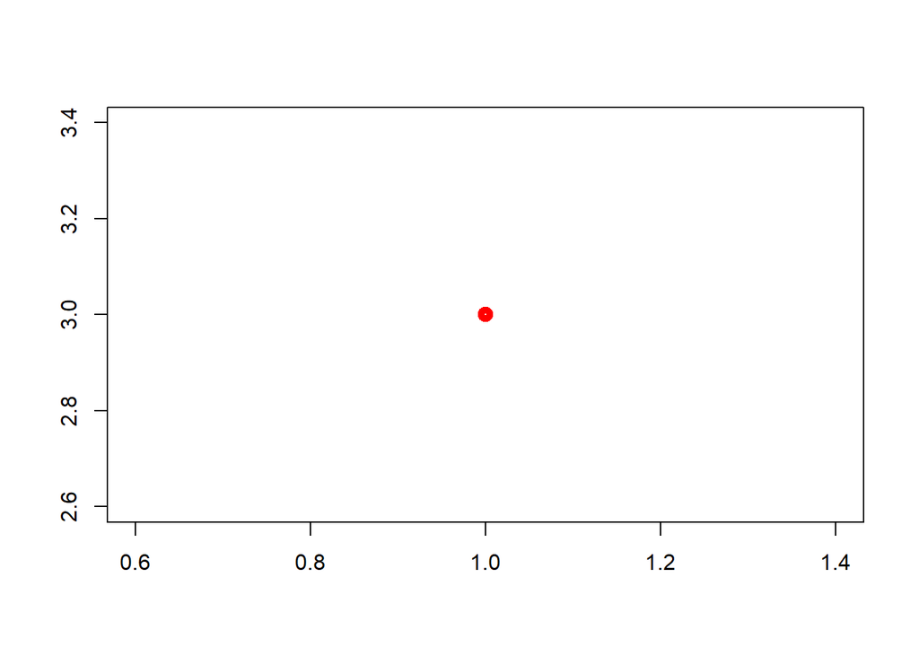

```r
p <- st_point(c(1, 3, 4)) # tri-dimensional point

plot(p,
     axes = T,
     lwd  = 5,
     col  = "red")
```

#### Creation of multi-point objects

The input must be a matrix, in this case given by the *rbind()* function.

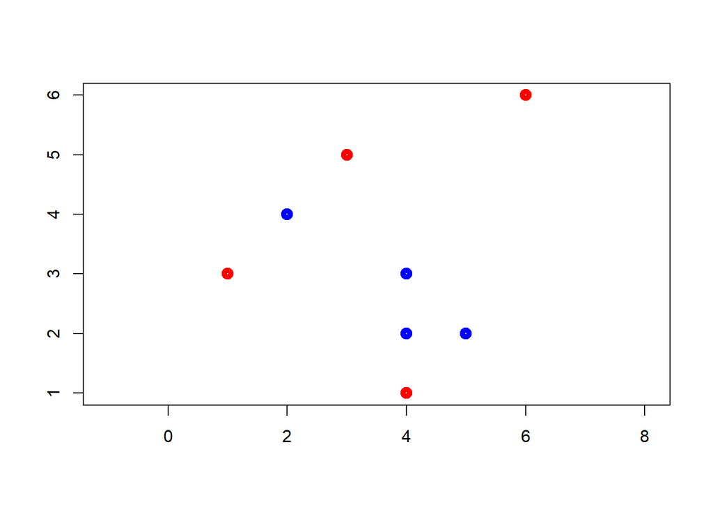

```r
mp <- st_multipoint(rbind(c(4, 1),
                          c(1, 3),
                          c(3, 5),
                          c(6, 6)))

mp2 <- st_multipoint(rbind(c(4, 3),
                           c(2, 4),
                           c(5, 2),
                           c(4, 2)))

plot(mp,
     axes  = T,
     lwd   = 5,
     col   = "red",
     reset = F)

plot(mp2,
     axes = T,
     lwd  = 5,
     col  = "blue",
     add  = T)
```

#### Line object creation

The geometry input must be a matrix.

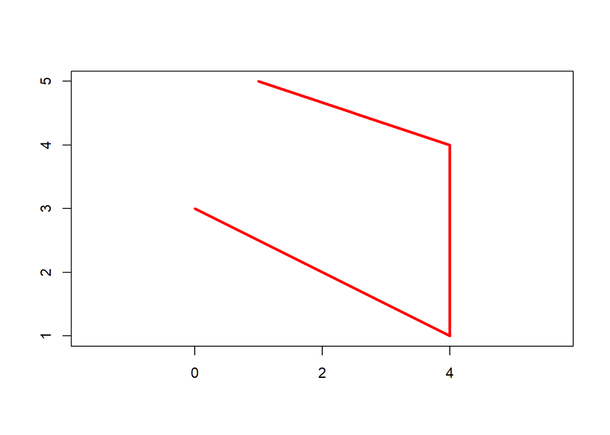

```r
l <- st_linestring(rbind(c(1, 5),
                         c(4, 4),
                         c(4, 1),
                         c(0, 3)))

plot(l,
     axes = T,
     lwd  = 3,
     col  = "red")
```

#### Multiline object creation

The geometry is entered through a list containing the different segments of the line.

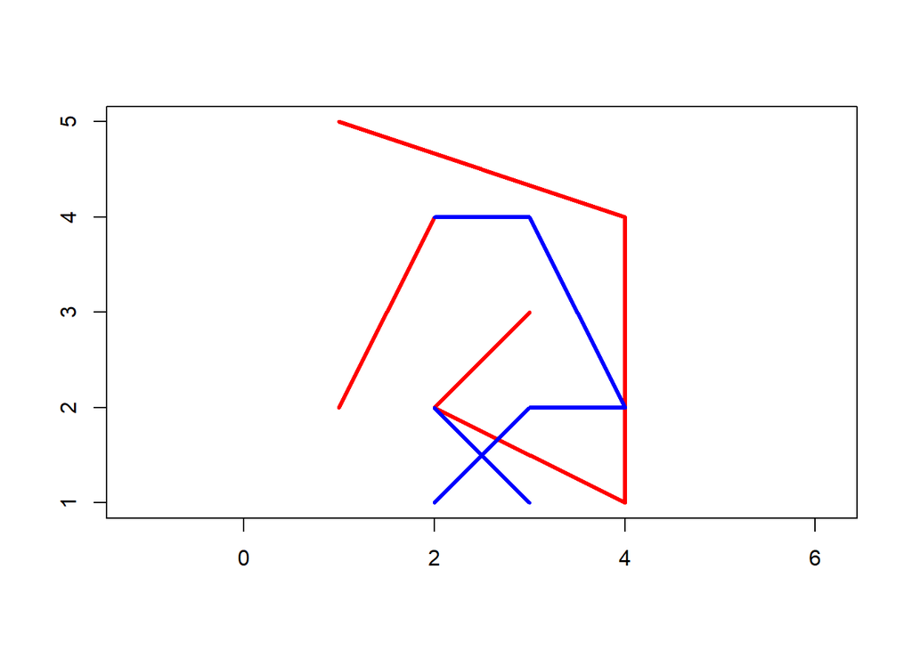

```r
ml <- st_multilinestring((list(rbind(c(1, 5),
                                     c(4, 4),
                                     c(4, 1),
                                     c(2, 2),
                                     c(3, 3)),
                               rbind(c(1, 2),
                                     c(2, 4)))))

ml2 <- st_multilinestring((list(rbind(c(2, 4),
                                      c(3, 4),
                                      c(4, 2),
                                      c(3, 2),
                                      c(2, 1)),
                                rbind(c(2, 2),
                                      c(3, 1)))))

plot(ml,
     col   = "red",
     axes  = T,
     lwd   = 3,
     reset = F)
plot(ml2,
     col = "blue",
     add = T,
     lwd = 3)
```

#### Polygon creation

Similar to multiline, it uses a list but with the difference that the start and end points are identical, to indicate the polygon closure.

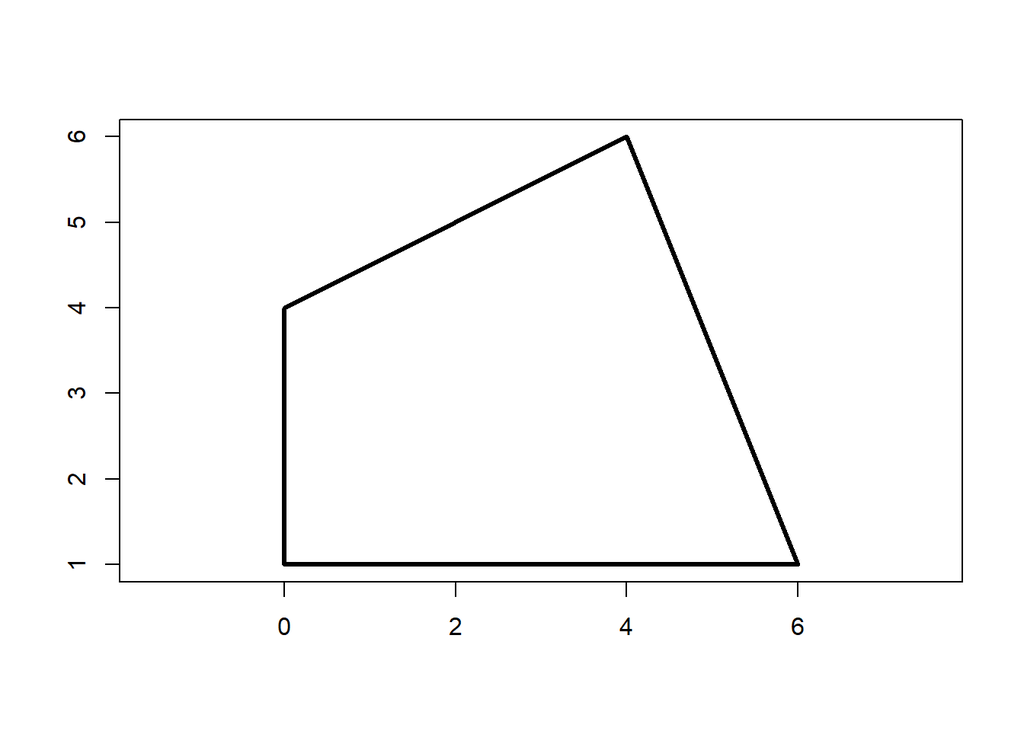

```r
pol <- st_polygon(list(rbind(c(0, 1),
                             c(0, 4),
                             c(4, 6),
                             c(6, 1),
                             c(0, 1))))

plot(pol,
     lwd   = 3,
     axes  = T)
```

#### **geometrycollection**

**geometrycollection** is a combination of the different objects already presented.

```r
geomcol <- c(st_geometrycollection(list(mp,
                                        mp2,
                                        ml,
                                        ml2,
                                        pol)))
st_geometry_type(geomcol) # what kind of object is?
```

```
## [1] GEOMETRYCOLLECTION
## 18 Levels: GEOMETRY POINT LINESTRING POLYGON MULTIPOINT ... TRIANGLE
```

Visualization, access is made through square brackets, the access order is the same as the creation of the collection.

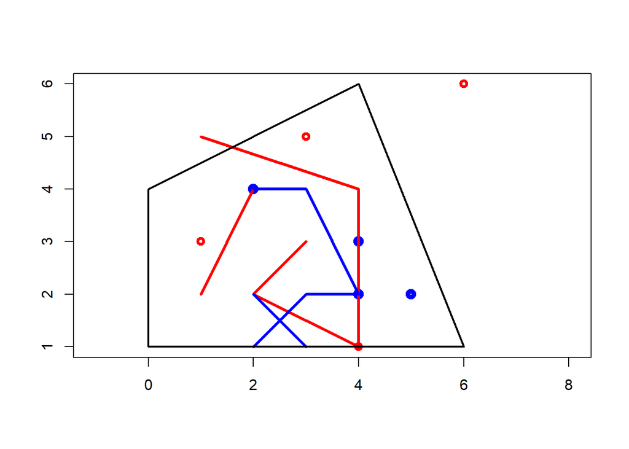

```r
plot(geomcol[[1]],
                 axes  = T,
                 col   = "red",
                 lwd   = 3,
                 reset = F)
plot(geomcol[[2]], col = "blue",  add = T, lwd = 5)
plot(geomcol[[3]], col = "red",   add = T, lwd = 3)
plot(geomcol[[4]], col = "blue",  add = T, lwd = 3)
plot(geomcol[[5]],                add = T, lwd = 2)
```

### 2. creating a **geometrycollection** object from ESRI-like layer file (shp)

We are going to build a **geometrycollection** from two layer files, a multi-polygon from the states of Brazil and the other layer a multi-point one, with the capitals of each of the 27 states. The two files were downloaded in 2019 from the IBGE portal https://www.ibge.gov.br/geociencias/organizacao-do-territorio/estrutura-territorial.html.

The files can be also downloaded from the dropbox site, using the link https://www.dropbox.com/sh/ogz8vy5wgtp9n9w/AAAuE3b_0Hf3b2is7OyTFQpIa?dl=1 in the form of a zip file. The files must be decompress, copy to your local directory and update the link to them in the following chunks.

#### First file, locally stored

```r
# update the link to your needs
path <- 'C:/Users/Walter Pina/Documents/bases/br_uf_2019.shp'
brasil <- read_sf(path) # Brazilian states, IBGE 2019
```

#### Simplifying the outline of Brazil and states

When the full precision of one object is not necessary, we can simplify it in order to facilitate its storage, manipulation or visualization. We check its size before and after simplification, the process may take several attempts to arrive at an appropriate view and size.

```r
cat("Size of the initial Brazil object = ", object.size(brasil), "bytes")
```

```
## Size of the initial Brazil object =  15018304 bytes
```

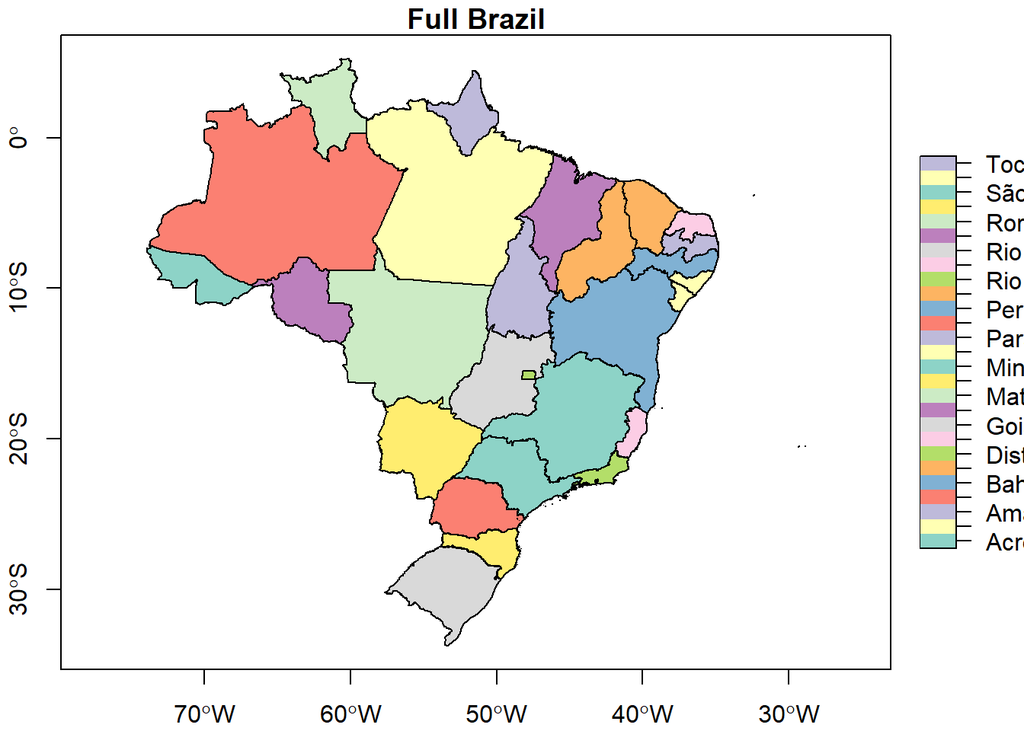

```r
plot(brasil["nm_uf"], axes = T, main = "Full Brazil")
```

The simplification factor must be compatible with the *CRS* of the file, in this case we have geographic coordinates, so *dTolerance = 0.1* corresponds to a tenth of a degree or approximately 11 km.

```r
brasil_simples <- st_simplify(brasil,
                              dTolerance       = 0.1,
                              preserveTopology = T)
```

```r
cat("Final size = ", object.size(brasil_simples), "bytes")
```

```
## Final size =  462272 bytes
```

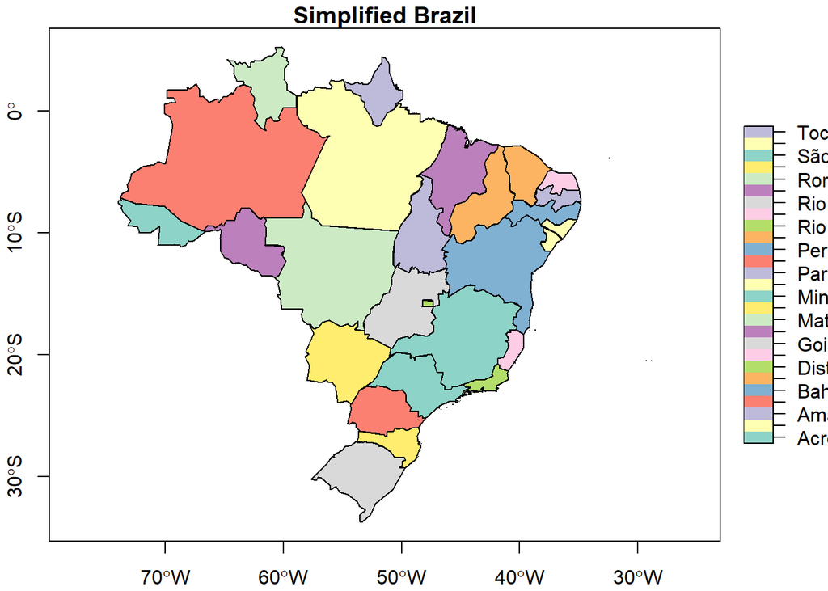

```r
plot(brasil_simples["nm_uf"], axes = T, main = "Simplified Brazil")
```

*CRS* verification

```r
st_crs(brasil_simples)
```

```
## Coordinate Reference System:
##   User input: SIRGAS 2000
##   wkt:
## GEOGCRS["SIRGAS 2000",
##     DATUM["Sistema de Referencia Geocentrico para las AmericaS 2000",
##         ELLIPSOID["GRS 1980",6378137,298.257222101,
##             LENGTHUNIT["metre",1]]],
##     PRIMEM["Greenwich",0,
##         ANGLEUNIT["degree",0.0174532925199433]],
##     CS[ellipsoidal,2],
##         AXIS["geodetic latitude (Lat)",north,
##             ORDER[1],
##             ANGLEUNIT["degree",0.0174532925199433]],
##         AXIS["geodetic longitude (Lon)",east,
##             ORDER[2],
##             ANGLEUNIT["degree",0.0174532925199433]],
##     USAGE[
##         SCOPE["unknown"],
##         AREA["Latin America - SIRGAS 2000 by country"],
##         BBOX[-59.87,-122.19,32.72,-25.28]],
##     ID["EPSG",4674]]
```

Extraction of multi-polygon geometry, for later combination in a **geometrycollection** .

```r
br_geom <- st_geometry(brasil_simples, value = NULL) # value = NULL exclude attributes
```

#### Second file

```r
# State capitals for Brazil
path2 <- 'C:/Users/Walter Pina/Documents/bases/Cadastro de localidades/capitais.shp'
capitais <- read_sf(path2)
```

*CRS* verification

```r
st_crs(capitais) # verifica CRS
```

```
## Coordinate Reference System:
##   User input: Geographic Coordinate System
##   wkt:
## GEOGCRS["Geographic Coordinate System",
##     DATUM["WGS84",
##         ELLIPSOID["WGS84",6378137,298.257223560493,
##             LENGTHUNIT["metre",1,
##                 ID["EPSG",9001]]]],
##     PRIMEM["Greenwich",0,
##         ANGLEUNIT["degree",0.0174532925199433]],
##     CS[ellipsoidal,2],
##         AXIS["longitude",east,
##             ORDER[1],
##             ANGLEUNIT["degree",0.0174532925199433]],
##         AXIS["latitude",north,
##             ORDER[2],
##             ANGLEUNIT["degree",0.0174532925199433]]]
```

```r
capitais <- st_transform(capitais, 4674) # transformação para SIRGAS 2000
st_crs(capitais) # verificação
```

```
## Coordinate Reference System:
##   User input: EPSG:4674
##   wkt:
## GEOGCRS["SIRGAS 2000",
##     DATUM["Sistema de Referencia Geocentrico para las AmericaS 2000",
##         ELLIPSOID["GRS 1980",6378137,298.257222101,
##             LENGTHUNIT["metre",1]]],
##     PRIMEM["Greenwich",0,
##         ANGLEUNIT["degree",0.0174532925199433]],
##     CS[ellipsoidal,2],
##         AXIS["geodetic latitude (Lat)",north,
##             ORDER[1],
##             ANGLEUNIT["degree",0.0174532925199433]],
##         AXIS["geodetic longitude (Lon)",east,
##             ORDER[2],
##             ANGLEUNIT["degree",0.0174532925199433]],
##     USAGE[
##         SCOPE["unknown"],
##         AREA["Latin America - SIRGAS 2000 by country"],
##         BBOX[-59.87,-122.19,32.72,-25.28]],
##     ID["EPSG",4674]]
```

A CRS transformation was performed because the file is native defined in WGS84, different from the previous one.

Extraction of multi-point geometry for later combination in a **geometrycollection**

```r
cap_geom <- st_geometry(capitais, value = NULL)
```

**It should be noted that for the right creation of the geometrycollection, the CRS of all objects included must be the same.**

#### Creation of a **geometrycollection** object

Using the geometries in *cap_geom* and *br_geom*, we create the **geometrycollection** object.

–

```r
br_geom_coll <- c(st_geometrycollection(cap_geom),
                  st_geometrycollection(br_geom))

st_geometry_type(br_geom_coll) # verifiyng the type
```

```
## [1] GEOMETRYCOLLECTION
## 18 Levels: GEOMETRY POINT LINESTRING POLYGON MULTIPOINT ... TRIANGLE
```

```r
class(br_geom_coll)
```

```
## [1] "XY"                 "GEOMETRYCOLLECTION" "sfg"
```

#### Data extraction

If we have an object of type **geometrycollection** in our global environment, the extraction of geometries can be done in a very simple way with the function *st_collection_extract()*, with the argument *type* indicating whether if a “POINT”, “LINE” or “POLYGON”. See https://r-spatial.github.io/sf/reference/st_collection_extract.html

Extraction and visualization of capitals.

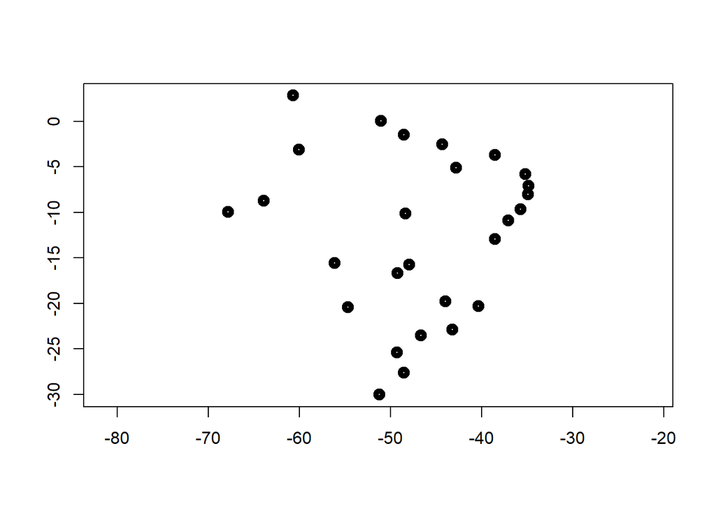

```r
br_cap <- st_collection_extract(
                                br_geom_coll,
                                type = c("POINT"),
                                warn = FALSE)

plot(br_cap, axes = T, lwd =5)
```

Extraction and visualization of states.

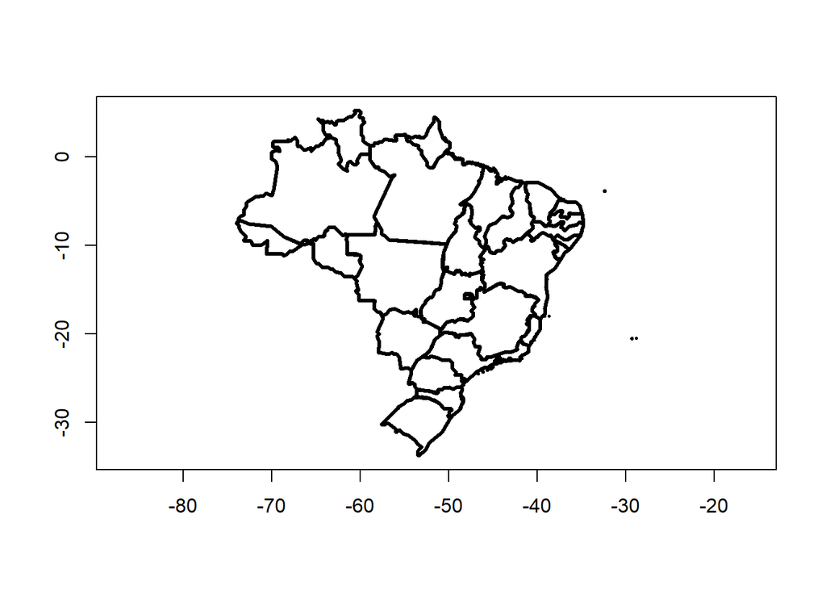

```r
br_uf  <- st_collection_extract(
                                br_geom_coll,
                                type = c("POLYGON"),
                                warn = FALSE)
plot(br_uf, axes = T, lwd =3)
```

#### The whole graphic

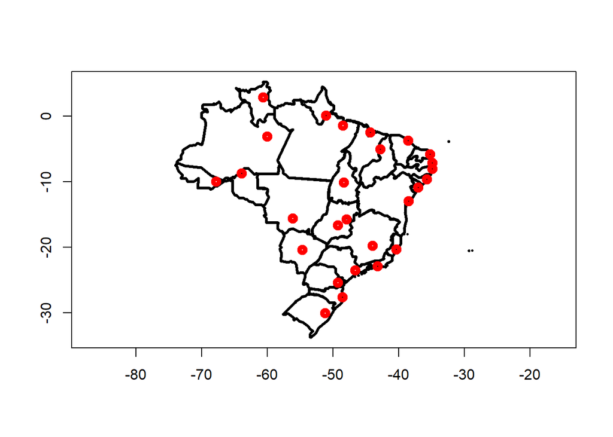

```r
plot(br_uf,
     reset = F,
     lwd   = 3,
     axes  = T)

plot(br_cap,
     add = T,
     col = "red",
     lwd = 5)
```

### 3. **geometrycollection** saving in Postgre / Postgis database

In order to load the **geometrycollection** in the database, the object class **sfg** have to be converted, first into **sfc** class and then into **sf**.

```r
br_geom <- st_sfc(br_geom_coll, crs = 4674) # geometry_collection to sfc, adding CRS

br_geo <- st_sf(br_geom)                    # sfc to sf
```

Having the **sf** *br_geo* object, we need to establish a connection with the database (using *RPostgres* library). In the following chunk there are local arguments to my Postgres database for loading the object.

```r
library(RPostgres)
con <- dbConnect(Postgres(),
                            user     = 'postgres',
                            password = 'postgres',
                            dbname   = 'r_databases',
                            port     = 5433)

#
dbWriteTable(con, "br_geo", br_geo, overwrite = T )
dbDisconnect(con)
```

#### Reading from the Postgres database with *RPostgres* library.

In the following chunk it can be included SQL commands to capture all or part of the desired table. Now we have a **geometrycollection sf** object stored in a Postgres database and we are going to read the *br_geo* file back.

```r
try(conn <- dbConnect(Postgres(),
                               user     = 'postgres',
                               password = 'postgres',
                               dbname   = 'r_databases',
                               port     = 5433))

if (exists("conn") && !inherits(conn, "try-error")) {
  br_geom_db = st_read(conn,
                       query = "select * from br_geo;")
  print(st_crs(br_geom_db)) # CRS will be given by the database file CRS!
  dbDisconnect(conn)
 }
```

```
## Coordinate Reference System:
##   User input: EPSG:4674
##   wkt:
## GEOGCRS["SIRGAS 2000",
##     DATUM["Sistema de Referencia Geocentrico para las AmericaS 2000",
##         ELLIPSOID["GRS 1980",6378137,298.257222101,
##             LENGTHUNIT["metre",1]]],
##     PRIMEM["Greenwich",0,
##         ANGLEUNIT["degree",0.0174532925199433]],
##     CS[ellipsoidal,2],
##         AXIS["geodetic latitude (Lat)",north,
##             ORDER[1],
##             ANGLEUNIT["degree",0.0174532925199433]],
##         AXIS["geodetic longitude (Lon)",east,
##             ORDER[2],
##             ANGLEUNIT["degree",0.0174532925199433]],
##     USAGE[
##         SCOPE["unknown"],
##         AREA["Latin America - SIRGAS 2000 by country"],
##         BBOX[-59.87,-122.19,32.72,-25.28]],
##     ID["EPSG",4674]]
```

Checking the geometry of the object.

```r
st_geometry_type(br_geom_db)
```

```
## [1] GEOMETRYCOLLECTION
## 18 Levels: GEOMETRY POINT LINESTRING POLYGON MULTIPOINT ... TRIANGLE
```

Finally, to verify the integrity of the object read, we will repeat the reading of the contour of Brazil and its 27 states.

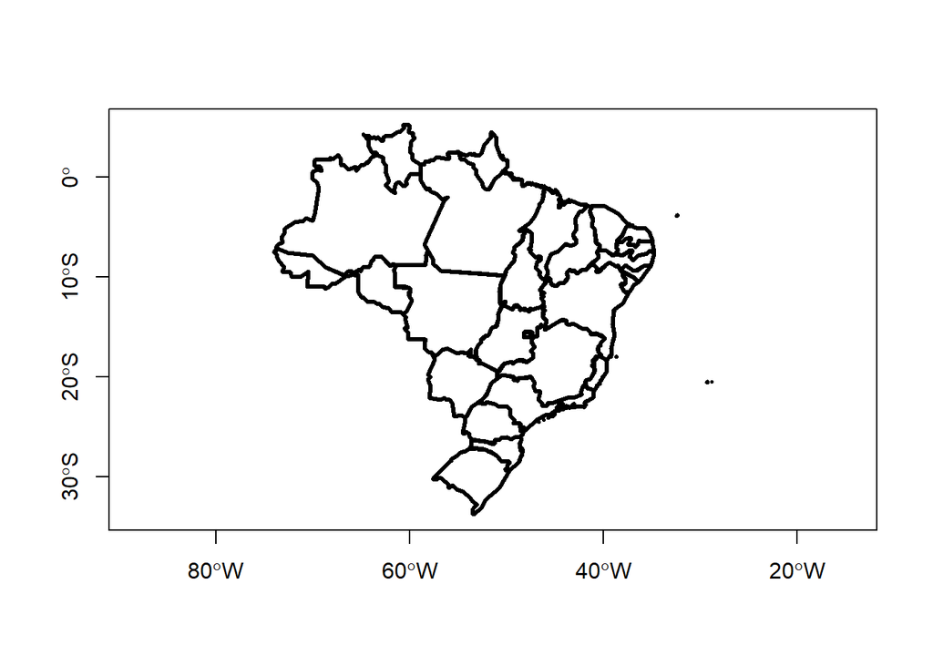

```r
br_uf  <- st_collection_extract(
                                br_geom_db,
                                type = c("POLYGON"),
                                warn = FALSE)
plot(br_uf, axes = T, lwd =3)
```

REFERENCES

CREDITOS:

- Pebesma, E., 2018. Simple Features for R: Standardized Support for Spatial Vector Data. The R Journal, https://journal.r-project.org/archive/2018/RJ-2018-009/